# Homework 1

### Question 3

Remake the previous scatter plot, but this time color the points by the cyl column.

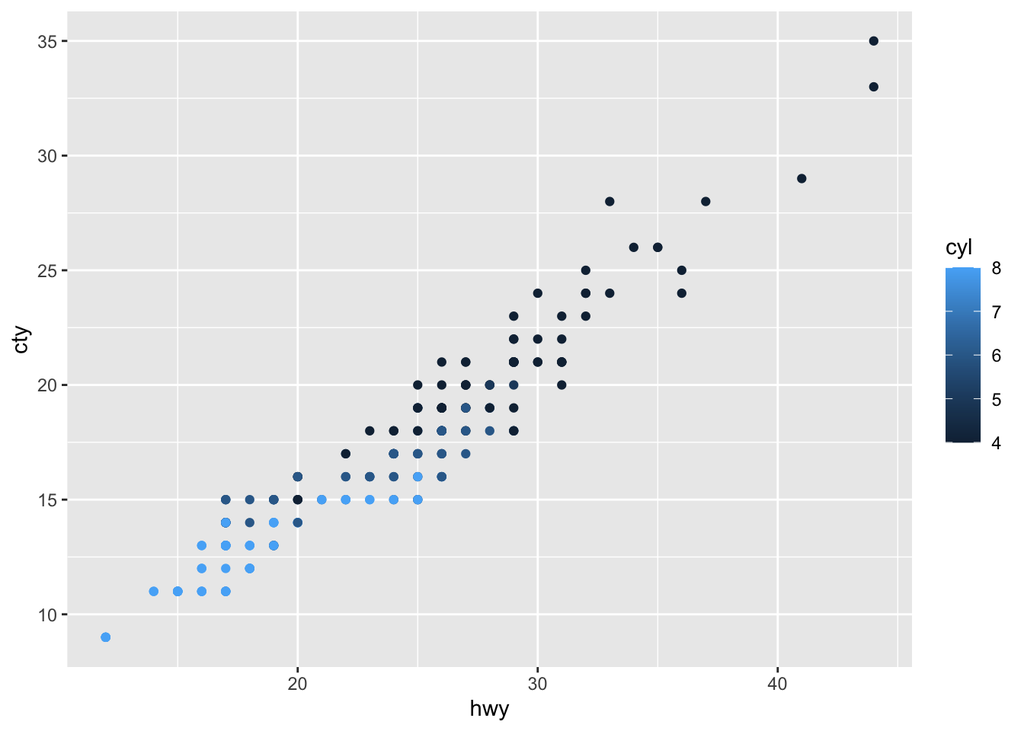

```r
## Fill in the blanks for Question 3 here:
ggplot(data = mpg, aes(x = hwy, y = cty, col = cyl)) + geom_point()
```

### Question 4

Make a scatterplot of displ vs cty colored by manufacturer.

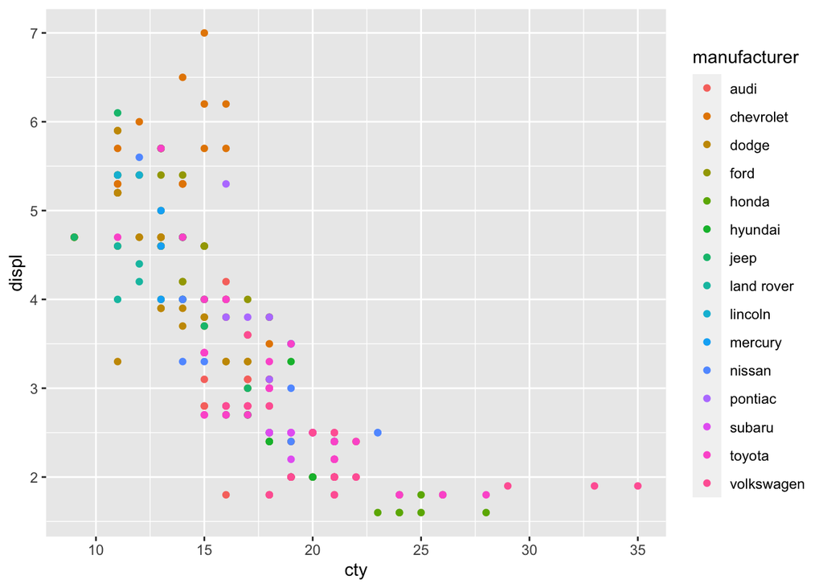

```r
## Insert code here
ggplot(data = mpg, aes(x = cty, y = displ, col = manufacturer)) + geom_point()
```

### Question 5 a)

Make a histogram of displ. Make sure that displ is on the x-axis.

(You may get a warning about saying “`stat_bin()` using `bins = 30`. Pick better value with `binwidth`.” Don’t worry about it, its just saying that there are currently 30 bins, but you may want a different number. We will try to get rid of this warning in question 5d)

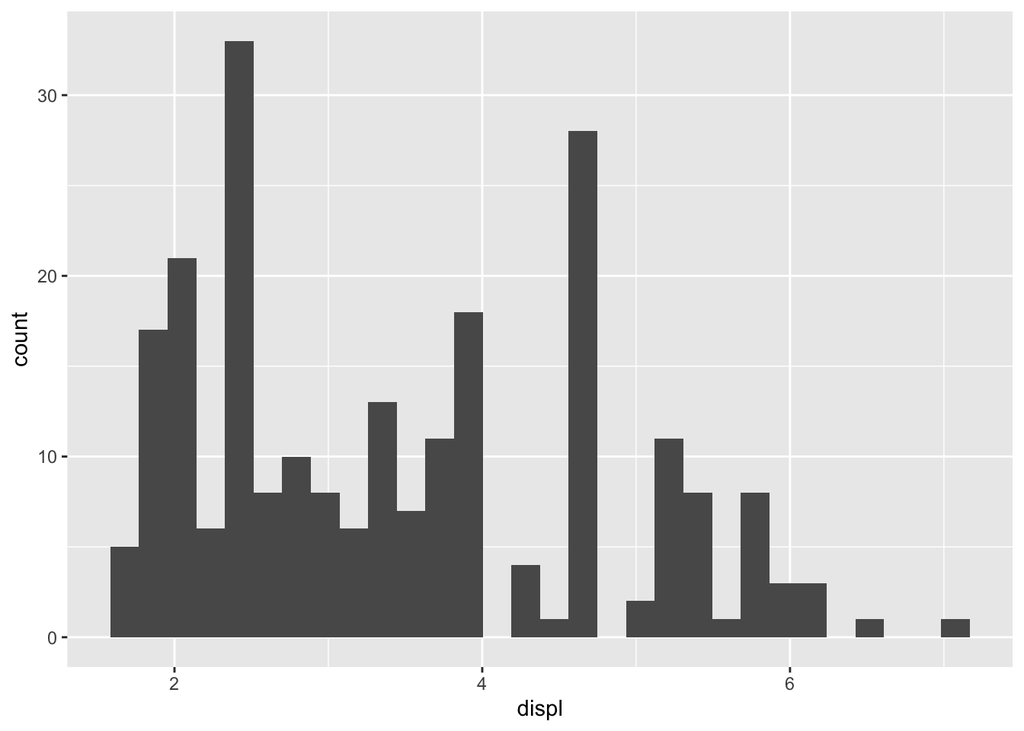

```r
## Insert code here
ggplot(data = mpg, aes(x = displ)) + geom_histogram()
```

### Question 5 b)

Remake a histogram of displ, but this time, put displ is on the y-axis and make the histogram purple!

- Hint: You will want to change the fill under geom_histogram()

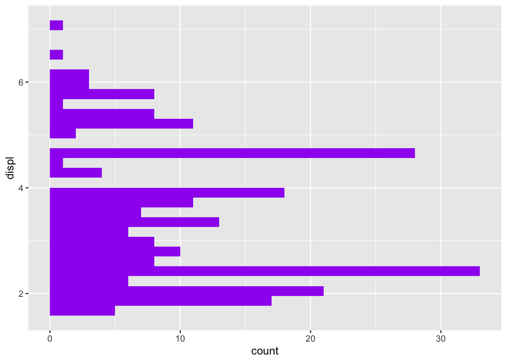

```r
## Insert code here
ggplot(data = mpg, aes(y = displ)) + geom_histogram(fill = "purple")
```

### Question 5 c)

Remake a histogram of displ, but this time, put displ is on the x-axis again and fill the histogram by the fl column.

*Hint: Now you will not set fill under geom_histogram(), instead set the fill similarly to how you set the color in question 3.

(This histogram will look weird because all of the different fl’s will be on top of each other.)

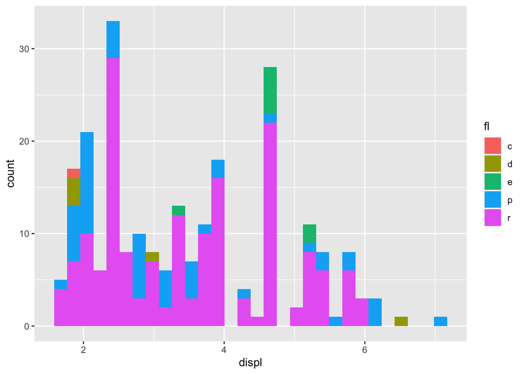

```r
## Insert code here
ggplot(data = mpg, aes(x = displ)) + geom_histogram(aes(fill = fl))
```

### Question 5 d)

Try getting rid of the stat_bin warning. Remake the simple histogram of displ from a, but set the number of bins to be 15.

- Hint: you will need to set `bins = 15` under geom_histogram()

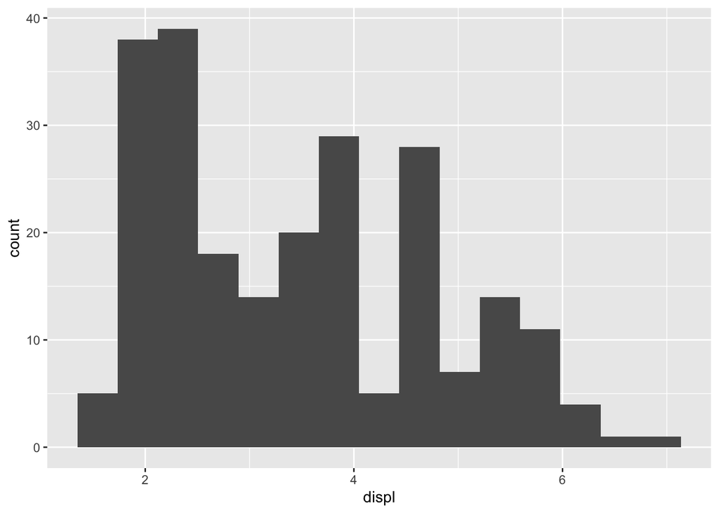

```r
ggplot(data = mpg, aes(x = displ)) + geom_histogram(bins = 15)
```

### Bonus Question

Try knitting this document! It should hopefully create an html file when you have finished the questions.